# si670-hw1-yuacheng

## SI 670 Applied Machine Learning, Week 1: A simple classification task (Due 09/14 11:59pm)

For this assignment, you will be using the Breast Cancer Wisconsin (Diagnostic) Database to create a classifier that can help diagnose patients. First, read through the description of the dataset (below). Then, try out the first one or two questions, which use basic numpy to prepare the data, so you can get familiar with the various columns, etc. Then use k-NN classifiers to learn and make predictions.

Each question is worth 20 points, for a total of 100 points. Correct answers and code receive full credit, but partial credit will be awarded if you have the right idea even if your final answers aren't quite right.

Submit your completed notebook file to the Canvas site - IMPORTANT: please name your submitted file si670-hw1-youruniqname.ipynb.

As a reminder, the notebook code you submit must be your own work. Feel free to discuss general approaches to the homework with classmates: if you end up forming more of a team discussion on multiple questions, please include the names of the people you worked with at the top of your notebook file.

```python
### Put your name here: Yuan Cheng
### Put your uniquename here: yuacheng
```

```python
# import required modules and load data file
!pip install matplotlib

import numpy as np
import pandas as pd
from sklearn.datasets import load_breast_cancer
import matplotlib.pyplot as plt

cancer = load_breast_cancer()

# print(cancer.DESCR)  # print the data set description
```

```
  Using cached cycler-0.10.0-py2.py3-none-any.whl (6.5 kB)
```

The object returned by `load_breast_cancer()` is a scikit-learn Bunch object, which is similar to a dictionary.

```python
cancer.keys()
```

```
dict_keys(['data', 'target', 'frame', 'target_names', 'DESCR', 'feature_names', 'filename'])
```

```python
cancer.feature_names
```

```
array(['mean radius', 'mean texture', 'mean perimeter', 'mean area',
       'mean smoothness', 'mean compactness', 'mean concavity',
       'mean concave points', 'mean symmetry', 'mean fractal dimension',
       'radius error', 'texture error', 'perimeter error', 'area error',
       'smoothness error', 'compactness error', 'concavity error',
       'concave points error', 'symmetry error',
       'fractal dimension error', 'worst radius', 'worst texture',
       'worst perimeter', 'worst area', 'worst smoothness',
       'worst compactness', 'worst concavity', 'worst concave points',
       'worst symmetry', 'worst fractal dimension'], dtype='<U23')
```

### Question 1

Scikit-learn works with lists, numpy arrays, scipy-sparse matrices, and pandas DataFrames, so converting the dataset to a DataFrame is not necessary for training this model. Using a DataFrame does however help make many things easier such as manipulating data, so let's practice creating a classifier with a pandas DataFrame.

Convert the sklearn.dataset `cancer` to a DataFrame.

- This function should return a `(569, 31)` DataFrame with columns =

```
['mean radius', 'mean texture', 'mean perimeter', 'mean area',
'mean smoothness', 'mean compactness', 'mean concavity',
'mean concave points', 'mean symmetry', 'mean fractal dimension',
'radius error', 'texture error', 'perimeter error', 'area error',
'smoothness error', 'compactness error', 'concavity error',
'concave points error', 'symmetry error', 'fractal dimension error',
'worst radius', 'worst texture', 'worst perimeter', 'worst area',
'worst smoothness', 'worst compactness', 'worst concavity',
'worst concave points', 'worst symmetry', 'worst fractal dimension',
'target']
```

and index =

```
RangeIndex(start=0, stop=569, step=1)
```

```python
def answer_one():

    df = pd.DataFrame(data= np.c_[cancer['data'], cancer['target']],columns= np.append(cancer['feature_names'],['target']))


    return pd.DataFrame(df)


# answer_one()
```

```python
df = answer_one()
print(df)
```

```
     mean radius  mean texture  mean perimeter  mean area  mean smoothness  \
0          17.99         10.38          122.80     1001.0          0.11840
1          20.57         17.77          132.90     1326.0          0.08474
2          19.69         21.25          130.00     1203.0          0.10960
3          11.42         20.38           77.58      386.1          0.14250
4          20.29         14.34          135.10     1297.0          0.10030
..           ...           ...             ...        ...              ...
564        21.56         22.39          142.00     1479.0          0.11100
565        20.13         28.25          131.20     1261.0          0.09780
566        16.60         28.08          108.30      858.1          0.08455
567        20.60         29.33          140.10     1265.0          0.11780
568         7.76         24.54           47.92      181.0          0.05263

     mean compactness  mean concavity  mean concave points  mean symmetry  \
0             0.27760         0.30010              0.14710         0.2419
```

[output cut: 51 more lines]

### Question 2

Using `train_test_split`, split the dataset into training and test sets `(X_train, X_test, y_train, and y_test)`.

**Set the random number generator state to 670 using `random_state=670` to make sure your results match ours**

```python
from sklearn.model_selection import train_test_split

def answer_two():
    df = answer_one()

    (X_train, X_test, Y_train, Y_test) = train_test_split(df[cancer.feature_names],df['target'], train_size=0.792,test_size=0.2, random_state=670)

    return X_train, X_test, Y_train, Y_test


# answer_two()
```

```python
X_train, X_test, Y_train, Y_test = answer_two()
print(X_train, X_test, Y_train, Y_test)
```

```
     mean radius  mean texture  mean perimeter  mean area  mean smoothness  \
400       17.910         21.02          124.40      994.0          0.12300
229       12.830         22.33           85.26      503.2          0.10880
243       13.750         23.77           88.54      590.0          0.08043
240       13.640         15.60           87.38      575.3          0.09423
91        15.370         22.76          100.20      728.2          0.09200
..           ...           ...             ...        ...              ...
20        13.080         15.71           85.63      520.0          0.10750
120       11.410         10.82           73.34      403.3          0.09373
332       11.220         19.86           71.94      387.3          0.10540
28        15.300         25.27          102.40      732.4          0.10820
548        9.683         19.34           61.05      285.7          0.08491

     mean compactness  mean concavity  mean concave points  mean symmetry  \
400           0.25760        0.318900             0.119800         0.2113
```

[output cut: 164 more lines]

### Question 3

Using KNeighborsClassifier, fit a k-nearest neighbors (knn) classifier with `n_neighbors = 5` on `X_train`, `y_train`. Then evaluate the classifier accuracy using `score` function on `X_test` and `y_test`.

*This function should return a tuple of (knn, accuracy), where*

- `knn` is a `sklearn.neighbors.classification.KNeighborsClassifier`
- `accuracy` is a `float` number returned by the `score` function

```python
from sklearn.neighbors import KNeighborsClassifier

def answer_three():
    X_train, X_test, y_train, y_test = answer_two()

    knn = KNeighborsClassifier(n_neighbors=5)
    knn.fit(X_train,Y_train)
    accuracy = knn.score(X_test, Y_test)

    return (knn, accuracy)


# answer_three()
```

```python
knn, accuracy = answer_three()
print(knn,accuracy)
```

```
KNeighborsClassifier() 0.9385964912280702
```

### Question 4

Recall in the fruits example in lab1, we found the feature scales matter. In this question, please examine the mean and standard deviation of `X_train`, and use the `sklearn.preprocessing.StandardScaler` to normalize the feature. Then train another knn (k=5) classifier and evaluate it.

*This function should return a tuple of (standardized_X_train, knn, accuracy), where*

- `standardized_X_train` is a `pandas.DataFrame` of the standardized features
- `knn` is a `sklearn.neighbors.classification.KNeighborsClassifier`
- `accuracy` is a `float` number returned by the `score` function

```python
from sklearn.preprocessing import StandardScaler


def answer_four(k=5):
    X_train, X_test, y_train, y_test = answer_two()

    # Your code here
    scaler_X_train = StandardScaler().fit(X_train)
    scaler_X_test = StandardScaler().fit(X_test)
    standardized_X_train = scaler_X_train.transform(X_train)
    standardized_X_test = scaler_X_test.transform(X_test)
    #
    #
    knn = KNeighborsClassifier(n_neighbors=5)
    knn.fit(standardized_X_train,Y_train)
    accuracy = knn.score(standardized_X_test,Y_test)

    return (standardized_X_train, knn, accuracy)


# answer_four()
```

```python
standardized_X_train, knn, accuracy = answer_four(k=5)
print(standardized_X_train, knn, accuracy)
```

```
[[ 1.12061319  0.39570954  1.38106932 ...  1.25312584  0.52923296
   1.93680125]
 [-0.33525382  0.69811661 -0.24487912 ...  1.27283229  0.78933248
   2.18305056]
 [-0.07159287  1.03053356 -0.10862181 ... -0.79846691 -0.40519867
  -1.15992057]
 ...
 [-0.79666049  0.12792922 -0.7982167  ... -1.41755253  0.60469393
  -1.04992921]
 [ 0.37261853  1.3768012   0.46714838 ...  1.34407867  1.78477511
   0.78544895]
 [-1.23714624  0.00788977 -1.25060757 ... -1.14105591 -0.58341501
  -0.2849147 ]] KNeighborsClassifier() 0.9649122807017544
```

### Question 5

Recall in the lecture and lab 1, we found the choice of k could affect the prediction accuracy. In this question, please train knn classifiers with `k = 1,2,...,20` and evaluate the classifiers by features normalized with `sklearn.preprocessing.StandardScaler` (similar to Question 4 with k changed). Next, please visualize how sensitive the k-NN classification accuracy is to the choice of the 'k' parameter by a scatter plot with the `x-axis` representing `k` and the `y-axis` representing `accuracy`.

- This function should get the accuracy under each k and store them in `accracy_list` for the scatter plot.

```python
def answer_five():
    k_range = range(1,21)
    accuracy_list = []

    scaler_X_train = StandardScaler().fit(X_train)
    scaler_X_test = StandardScaler().fit(X_test)
    standardized_X_train = scaler_X_train.transform(X_train)
    standardized_X_test = scaler_X_test.transform(X_test)

    for k in k_range:


        knn = KNeighborsClassifier(n_neighbors = k)
        knn.fit(standardized_X_train, Y_train)
        accuracy_list.append(knn.score(standardized_X_test, Y_test))



    plt.figure()
    plt.xlabel('k')
    plt.ylabel('accuracy')
    plt.scatter(k_range, accuracy_list)
    plt.xticks([0,5,10,15,20])
    plt.show()

# answer_five()
```

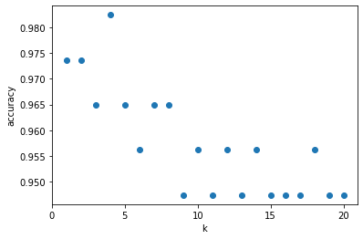

```python
answer_five()
```